# Part II - Factors that affect students' academic performance

## by David Owino

## Investigation Overview

> In this investigation, I wanted to look at the factors that affect performance among students in different regions, which are either members of OECD or Non-OECD. The main focus was on the choice of school, student gender, location, and attributes, and teachers' attributes and attitudes. These characteristics are found in the social, economic, and cultural status index, school desktop computer, perseverance, teacher-student relations, sense of belonging to a school, home possessions as well as the parental level of education columns.

## Dataset Overview

> The data consisted of scores and attributes of approximately 85934 students. The attributes included country, OECD, international grade, gender, age, school and home desktop computer usage, parental educational level, perseverance, sense of belonging to a school, ICT use at_school,teacher-student relations, teacher support, social economic&cultural index status, and home possessions. Thousands of data points were removed from the analysis because only main features of interest were retained while some were removed due to inconsistencies or missing information.

## Distribution of scores

Subject scores, mathematics, science, and reading in the dataset take on a range of values, from about 200 at the lowest, to about 800 at the highest. From the histogram, the distribution of scores follows a clear normal distribution. The distribution, of the total scores, is also normal, indicating that the scores could have been standardized.

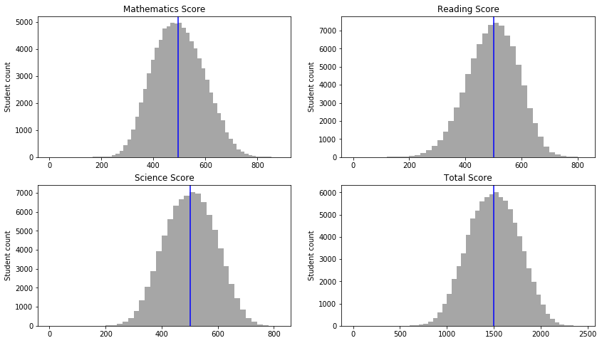

## Distribution of attribute numeric variables

The box plot shows that all the numeric variables, attributed to subject scores have outliers. Whereas most of the features are normally distributed, perseverance, ICT used at school, and teacher-student relations are slightly skewed.

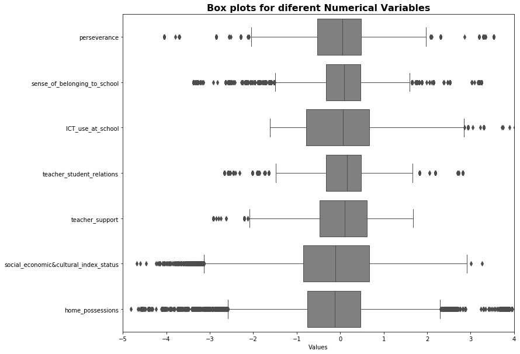

## Counts for parents educational level

The majority of the parents whose children were interviewed had post-secondary and post-graduate education.

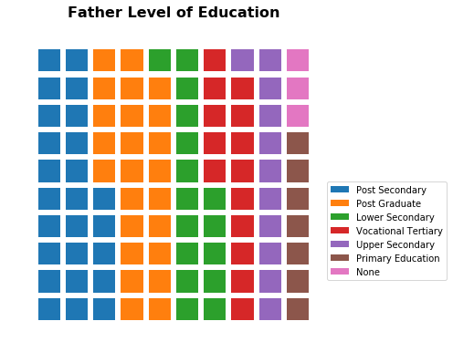

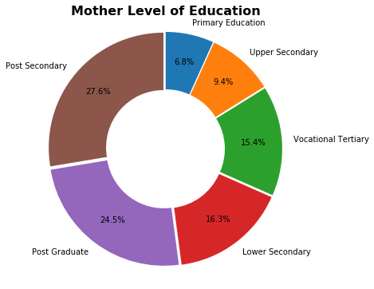

## Percentage proportion of students interviewed by grade

There is a greater percentage of students in grade 10 who took part in the pisa test.

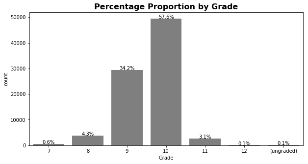

## Home vs. School computer usage

The number of students who access and use computers is 42043, which is higher than those who don't use a computer either at home or school whether they access the computers or not.

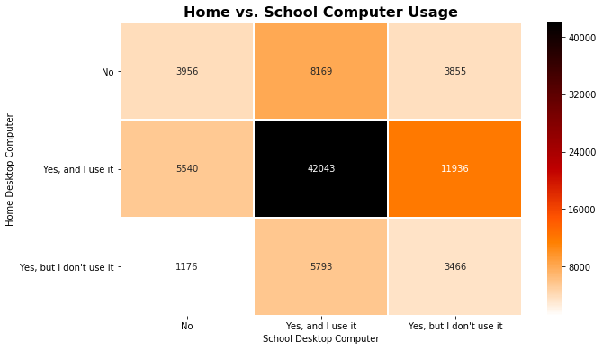

## Countries by region

- I want to concentrate only on observations from OECD members within the following regions, where students access and use desktop computers at school and have positive teacher support.

Western Europe countries comprise Austria, Belgium, France, Germany, Liechtenstein, Luxembourg, Netherlands, and Switzerland

Northern Europe countries comprise Denmark, Estonia, Finland, Iceland, Ireland, Latvia, Lithuania, Norway, Sweden, and United Kingdom

Transcontinental countries comprise Kazakhstan, Russian Federation, and Turkey

East Asia countries comprise China-Shanghai, Chinese Taipei, Macao-China, Hong Kong-China, and Japan

North America subregion includes Canada, Mexico, and the United States of America

## Social-Cultural and Economic status vs. Score

It is evident that there is a linear positive relationship between student scores and social, economic, and cultural status. Positive social-cultural and economic status have a positive impact on student performance among OECD countries in the transcontinental region.

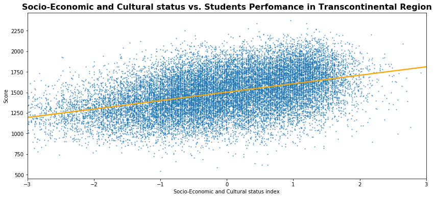

## Perseverance vs. Score

This shows a slight positive relationship between student scores and perseverance among countries in Northern Europe, though a lot of data seem to concentrate at zero suggesting that perseverance might not be a major factor for higher scores in this region.

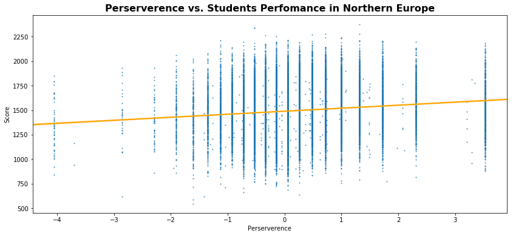

## Teacher-student relations vs. Score

A lot of data concentrates from zero to 1, suggesting that positive relations between students and teachers impact positively on the student scores in North American countries, which are members of OECD.

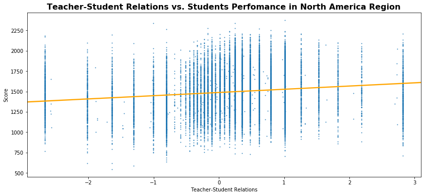

## Home possessions vs. Score

This shows a linear positive relationship between student scores and home possessions. Positive home possessions have a positive impact on student performance among OECD countries in Western Europe.

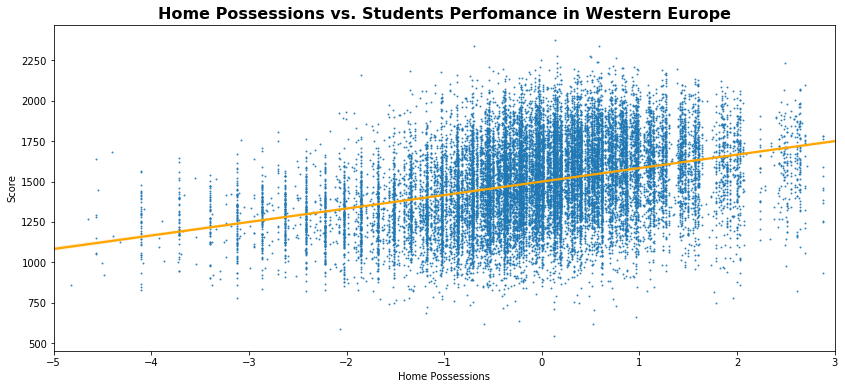

## Students sense of belonging to school vs. Score

A lot of data concentrates from zero to 1, suggesting that student positive feelings about their school impact positively on their scores in East Asia countries, which are members of OECD.

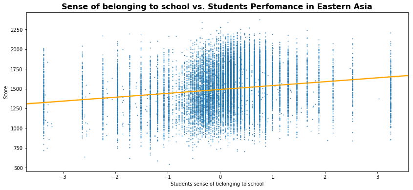

## ICT usage at school vs. Score

There is a slight linear negative relationship between student scores and student usage of ICT at school within Non-OECD states.

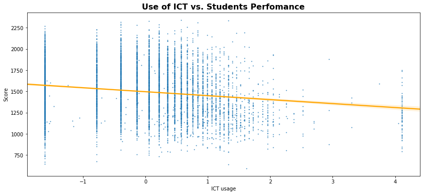

## Teachers' support vs. Score

A lot of data concentrates from zero to about 0.8, suggesting that positive teacher support impacts positively on students' scores.

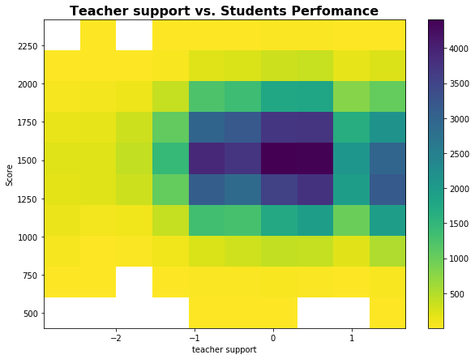

## Gender and OECD membership performance

There is no significant different in performance among females and males as well as between OECD and non-OECD memders.

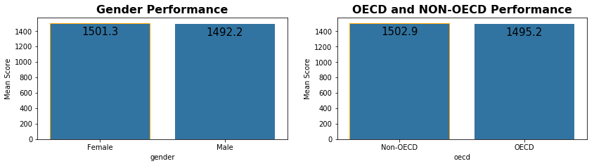

## Student perfomance per country of residence

China_Shanghai has the best perfomance.

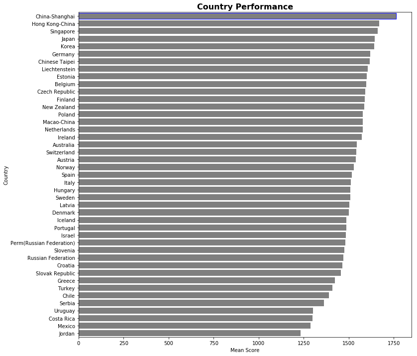

## Score by grade and gender

Male students in grade 7 performed lower than those in grade 12 compared to their female counterparts. There is no significant difference in scores among female and male students in the other grades.

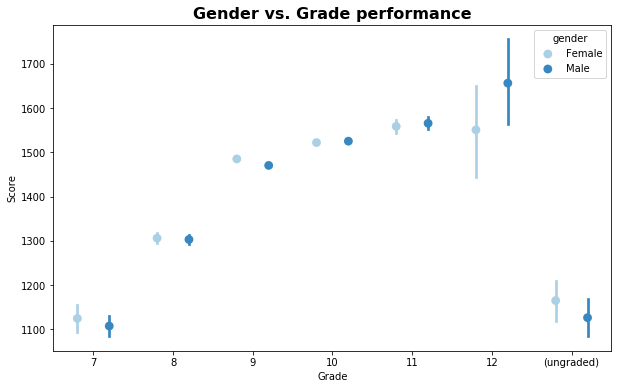

## Score by school desktop computer usage and grade

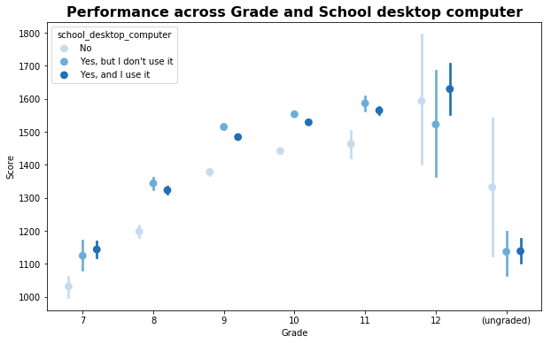

## Scores by gender and perseverance

The score tends to concentrate at zero, implying that the effect of perseverance on student performance is not significantly different for both male and female students.

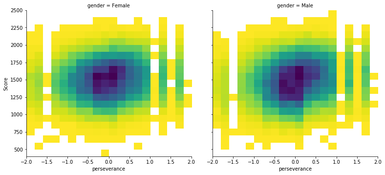

## Scores by gender and Teacher-Student Relations

Performance of male students seems to be positively influenced by teacher-student relations as compared to female students.

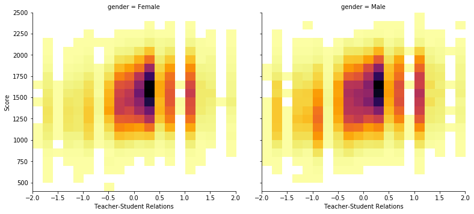

## Scores by gender and Sense of belonging to school

In this case, I considered sample data from OECD member states, where student access and use computers, and teachers' support is positive. Performance of male students seems to be positively influenced by sense of belonging to school as compared to male students.

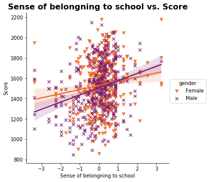

## Teacher-Student Relations vs. Sense of belonging by Gender and OECD

The relationship between teacher-student relations and a sense of belonging is a linear trend for both males and females as well as among the OECD members and non-members.

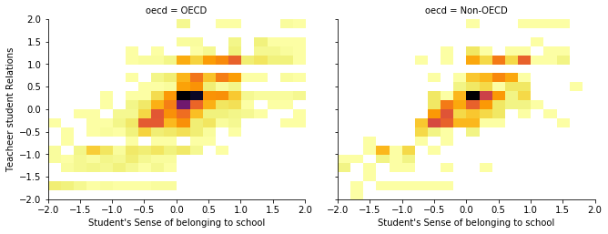

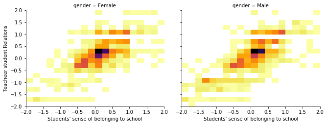

## Gender scores by parent level of education

Most of the students, males, and females who scored highest on the Pisa test had mothers attaining at least post-secondary education.

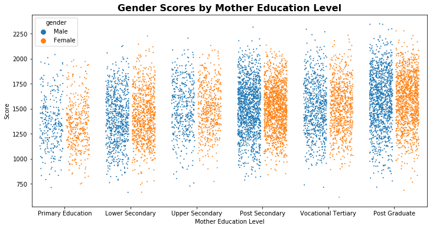